# Inference with RTMB

## RTMB Sockeye Ricker

```r
library(RTMB)

sox$stock <- as.numeric(factor(sox$PopName))
nstocks <- max(sox$stock)
set.seed(1)   ## random but reproducible starting values, in a plausible range
parameters <- list(
  alpha = runif(nstocks, 1, 3),
  logbeta = runif(nstocks, -1, 0),
  logsigma = runif(nstocks, -0.5, 0.5)
)

sox$logRS <- log(sox$recruits/sox$spawners)

negll <- function(pars){
  getAll(pars)
  beta <- exp(logbeta)
  sigma <- exp(logsigma)
  mu <- alpha[sox$stock] - beta[sox$stock]*sox$spawners_scaled
  -sum(dnorm(sox$logRS, mu, sigma[sox$stock], log = TRUE))
}
obj <- MakeADFun(func = negll, parameters = parameters, silent = TRUE)
```

## Find MLE

- Find minimum negative log likelihood
- Use `nlminb` by default and pass initial values, function, and gradient.
- `nlminb` gives up after 150 iterations or 200 function evaluations unless told otherwise.

```r
par_init <- obj$par + rnorm(length(obj$par), 0, 0.5)
mle <- nlminb(par_init, obj$fn, obj$gr, control = list(eval.max = 1e4, iter.max = 1e4))

## relist everything for convenience to access parameters by name
parList <- obj$env$parList(mle$par)
```

## Now What?

1. Check convergence
2. Transform parameters to real scale
3. Compute variance
4. Compute confidence intervals

## Convergence

- Check for error messages from optimization.

```r
mle$convergence
```

```
[1] 0
```

```r
mle$message
```

```
[1] "relative convergence (4)"
```

- Make sure all the gradient values are small

```r
max(abs(obj$gr(mle$par)))
```

```
[1] 0.0002851288
```

- Hessian should be positive definite: every eigenvalue positive. Being able to invert it is not enough.

```r
min(eigen(obj$he(mle$par), symmetric = TRUE)$values)
```

```
[1] 0.5325339
```

## Convergence

- If you are very thorough, you will try multiple starting points and make sure they all end up the same.
- Count the starts that fail. Quietly dropping them hides exactly the problem you are looking for.

```r
nll <- NULL
nfail <- 0
for( i in 1:50 ){
  par_init <- mle$par + rnorm(length(mle$par), 0, 1)
  mle_i <- nlminb(par_init, obj$fn, obj$gr, control = list(eval.max = 1e4, iter.max = 1e4))
  if(mle_i$convergence == 0){
    nll <- c(nll, mle_i$objective)
  }else{
    nfail <- nfail + 1
  }
}
nfail                 ## starts that did not converge
```

```
[1] 0
```

```r
max(nll) - min(nll)   ## spread of the ones that did
```

```
[1] 1.044746e-07
```

## Putting the Checks Together

- A small wrapper saves repeating these checks for every model.
- Newton steps polish the optimum. `optimHess` is used because it also works when there are random effects.

```r
fit_rtmb <- function(obj, newton_steps = 2){
  opt <- nlminb(obj$par, obj$fn, obj$gr, control = list(eval.max = 1e4, iter.max = 1e4))
  for( i in seq_len(newton_steps) ){
    g <- as.numeric(obj$gr(opt$par))
    h <- optimHess(opt$par, obj$fn, obj$gr)
    step <- try(solve(h, g), silent = TRUE)
    if(inherits(step, "try-error")) break
    new_obj <- obj$fn(opt$par - step)
    if(is.finite(new_obj) && new_obj <= opt$objective){   ## keep a step only if it helps
      opt$par <- opt$par - step
      opt$objective <- new_obj
    }else break
  }
  obj$fn(opt$par)   ## so that the best parameters are also the last ones evaluated
  sdr <- sdreport(obj, par.fixed = opt$par)
  se <- suppressWarnings(sqrt(diag(sdr$cov.fixed)))
  eig <- eigen(optimHess(opt$par, obj$fn, obj$gr), symmetric = TRUE, only.values = TRUE)$values
  checks <- c(nlminb_code_0 = opt$convergence == 0,
              small_gradient = max(abs(sdr$gradient.fixed)) < 1e-3,
              hessian_pos_def = all(eig > 0),
              finite_se = all(is.finite(se)))
  list(opt = opt, sdr = sdr, checks = checks)
}

checked <- fit_rtmb(obj)
checked$checks
```

```
  nlminb_code_0  small_gradient hessian_pos_def       finite_se
           TRUE            TRUE            TRUE            TRUE
```

```r
max(abs(checked$sdr$gradient.fixed))
```

```
[1] 3.436886e-07
```

## Transform Parameters

- `REPORT` to return value of variable
- `ADREPORT` to include uncertainty of variable
- `sdreport` will return standard deviations of parameters
- `as.list` of `sdreport` object will create a list of the parameters.

```r
negll <- function(pars){
  getAll(pars)
  beta <- exp(logbeta)
  sigma <- exp(logsigma)
  beta_real <- beta/sd_by_stock   ## back to the scale of unscaled spawners
  ADREPORT(beta)
  ADREPORT(beta_real)
  mu <- alpha[sox$stock] - beta[sox$stock]*sox$spawners_scaled
  -sum(dnorm(sox$logRS, mu, sigma[sox$stock], log = TRUE))
}
## We fitted to spawners_scaled = spawners/sd_spawners, so beta_real = beta/sd (one sd per stock)
sd_by_stock <- as.numeric(tapply(sox$sd_spawners, sox$stock, unique))

obj <- MakeADFun(negll, parameters, silent = TRUE)
fit <- nlminb(obj$par, obj$fn, obj$gr, control = list(eval.max = 1e4, iter.max = 1e4))
sdr <- sdreport(obj, fit$par)
res <- summary(sdr, "fixed")
res_real <- summary(sdr, "report")
res_real <- res_real[rownames(res_real) == "beta", ]   ## keep beta for the comparison below
```

## Compute Variance

- Variance or standard deviation is approximated by inverse of Hessian of negative log-likelihood,

$$V(\widehat{\boldsymbol{\theta}}) = H^{-1}(\widehat{\boldsymbol{\theta}}).$$

```r
H <- obj$he(fit$par)
V <- solve(H)
std_err <- sqrt(diag(V))
max(abs(res[, "Std. Error"] - std_err))
```

```
[1] 1.24906e-06
```

## Compute Variance of Transformed Variables

- Delta Method can be used to compute standard error of transformed variables, for transformation $g$,

$$V(g(\widehat{\boldsymbol{\theta}})) = \nabla g V(\widehat{\boldsymbol{\theta}}) \nabla g'.$$

- Showing to peak in ‘black box’ of how RTMB does this.
- For our example above:

$$\begin{align}
g(\alpha) & = \alpha \\
g'(\alpha) & = 1
\end{align}$$

$$\begin{align}
g(\log \beta) & = \exp(\log \beta) = \beta \\
g'(\log \beta) & = \exp(\log \beta) = \beta
\end{align}$$

- Code it in R and compare with RTMB

```r
which_alpha <- grepl("alpha", names(obj$par))
par_real <- MakeTape(
\(x){
  x[!which_alpha] <- exp(x[!which_alpha]);
  return(x)}, obj$par)
g <- par_real$jacobian(fit$par)

V_real <- g %*% V %*% t(g)
std_err_real <- sqrt(diag(V_real))
max(abs(res_real[, "Std. Error"] - std_err_real[grepl("beta", names(obj$par))]))
```

```
[1] 2.201883e-07
```

## Confidence Interval

- Typical format of 95% confidence interval (‘Wald’)
  $$\widehat{\beta} \pm z_{0.025} \, \text{sd}(\widehat{\beta})$$
- $z$ is a standard normal distribution. For a linear regression we know that the slope terms are $t$ distributed
- You can transform the end points of an interval to another scale (quantiles are transformation invariant). But a Wald interval *computed* on another scale is a different interval: compare the two on the next slide.

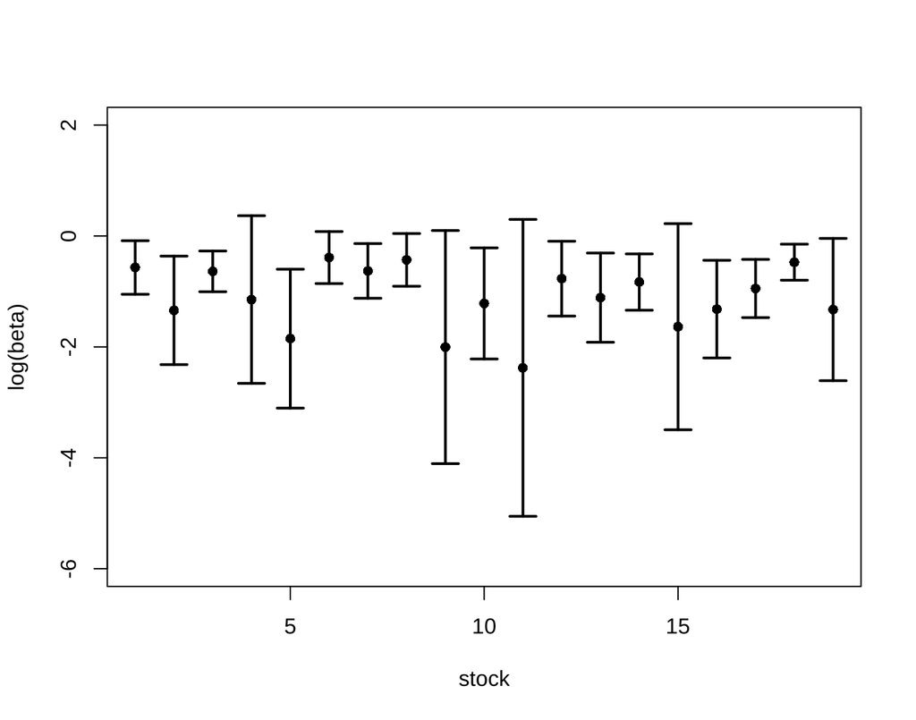

## Confidence Interval Transformed

- Compare confidence interval transformed vs transforming first and then computing confidence interval.

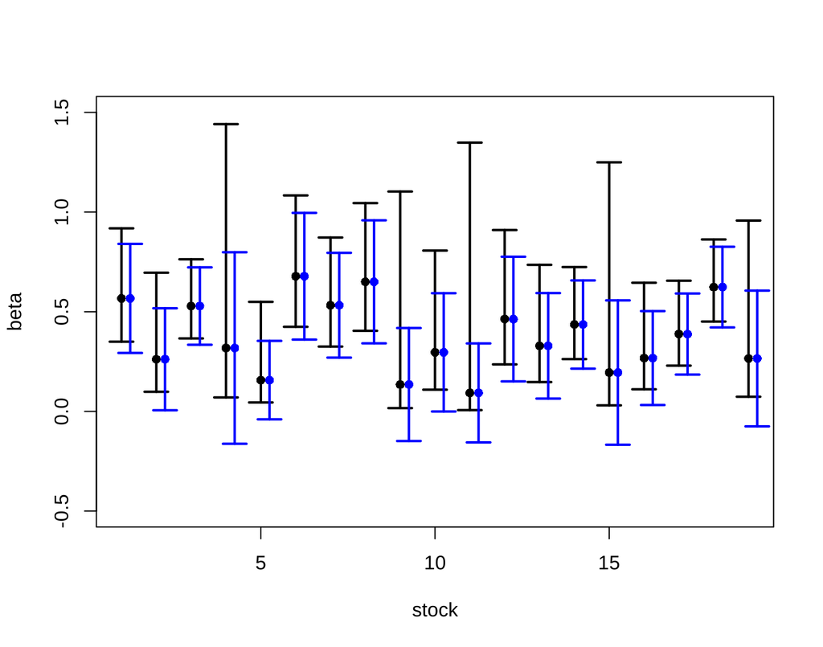

```r
low_tr <- exp(low_lbeta)
high_tr <- exp(high_lbeta)

beta <- as.list(sdr, "Est", report=TRUE)$beta ## parameter estimates
sd_beta <- as.list(sdr, "Std. Error", report=TRUE)$beta ## parameter estimates
low_r <- beta + qnorm(0.025)*sd_beta
high_r <- beta + qnorm(0.975)*sd_beta
nbeta <- length(beta)

plot(exp(logbeta), pch = 16, ylim = c(-0.5, 1.5), xlab = "stock", ylab = "beta")
arrows(1:nbeta, low_tr, 1:nbeta, high_tr, length = 0.1, angle = 90, code = 3, col = "black", lwd = 2)
points(1:nbeta+0.25, beta, pch = 16, col='blue')
arrows(1:nbeta+0.25, low_r, 1:nbeta+0.25, high_r, length = 0.1, angle = 90, code = 3, col = "blue", lwd = 2)
```

## Profile Confidence Interval

- Best confidence interval but computationally demanding
- Profile likelihood traverses a single parameter values, finds MLE for other values.
- The 95% interval is every value whose negative log-likelihood is within `qchisq(0.95, 1)/2 = 1.92` of the minimum (a likelihood ratio test), not an area under the curve.
- Takes into account skew of distribution etc.

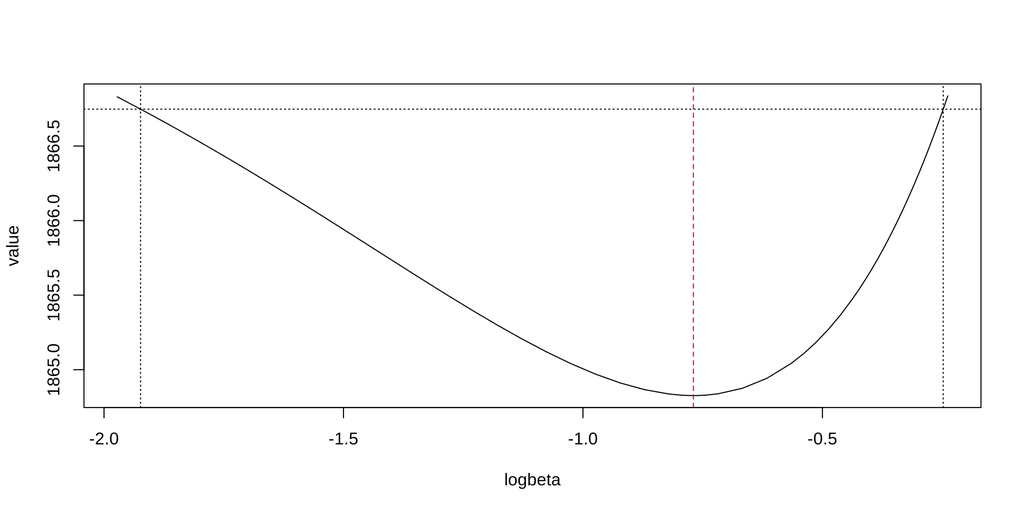

```r
i_prof <- which(names(obj$par) == "logbeta")[12]   ## log(beta) of stock 12
prof <- TMB::tmbprofile(obj, name = i_prof, trace = FALSE)
plot(prof)
abline(v = fit$par[i_prof], col = 'red', lty = 2)
```

```r
prof_int <- confint(prof)
```

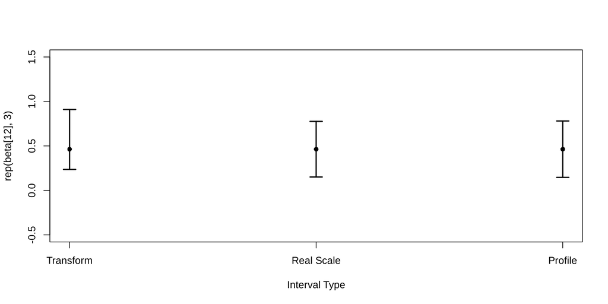

```r
plot(1:3, rep(beta[12], 3), ylim = c(-0.5, 1.5), pch = 16, xlab = "Interval Type", xaxt = "n")
axis(1, at = 1:3, labels = c("Transform", "Real Scale", "Profile"))

arrows(1:3, c(low_tr[12], low_r[12], exp(prof_int[1])), 1:3,
  c(high_tr[12], high_r[12], exp(prof_int[2])), length = 0.1, angle = 90,
  code = 3, col = "black", lwd = 2)
```

## Bootstrapped Confidence Interval

- Declare data as `OBS` to let RTMB recognize it as data.
- Do a data update so that you don’t have to retape each time `DataEval`
- After changing the data call `obj$force.update()`: the tape does not notice by itself.

```r
negll <- function(pars){
  getAll(pars, data, warn=FALSE)
  logRS <- DataEval(\(x){boot$logRS}) ## Updates the data.
  logRS <- OBS(logRS)
  beta <- exp(logbeta)
  sigma <- exp(logsigma)
  REPORT(beta)
  mu <- alpha[stock] - beta[stock]*spawners_scaled
  logRS %~% dnorm(mu, sigma[stock]) ## Alternative way to define likelihood...
}

data <- list(stock = sox$stock,
  spawners_scaled = sox$spawners_scaled
  )
boot <- list(logRS = sox$logRS)

obj <- MakeADFun(negll, parameters, silent = TRUE)
fit <- nlminb(obj$par, obj$fn, obj$gr, control = list(eval.max = 1e4, iter.max = 1e4))

set.seed(2)
boot.pars <- NULL
nflag <- 0
for( i in 1:1000 ){
  boot$logRS <- obj$simulate(fit$par)$logRS
  obj$force.update()                  ## tell the tape that the data changed
  newfit <- nlminb(fit$par, obj$fn, obj$gr, control = list(eval.max = 1e4, iter.max = 1e4))
  nflag <- nflag + (newfit$convergence != 0)
  newbeta <- obj$report(newfit$par)$beta
  boot.pars <- cbind(boot.pars, newbeta)
}
boot$logRS <- sox$logRS; obj$force.update()   ## put the real data back
## Refits flagged by nlminb. Look at them before deciding what to do: here they are all
## cases where a stock's beta is estimated at zero, a real outcome, so they are kept.
nflag
```

```
[1] 11
```

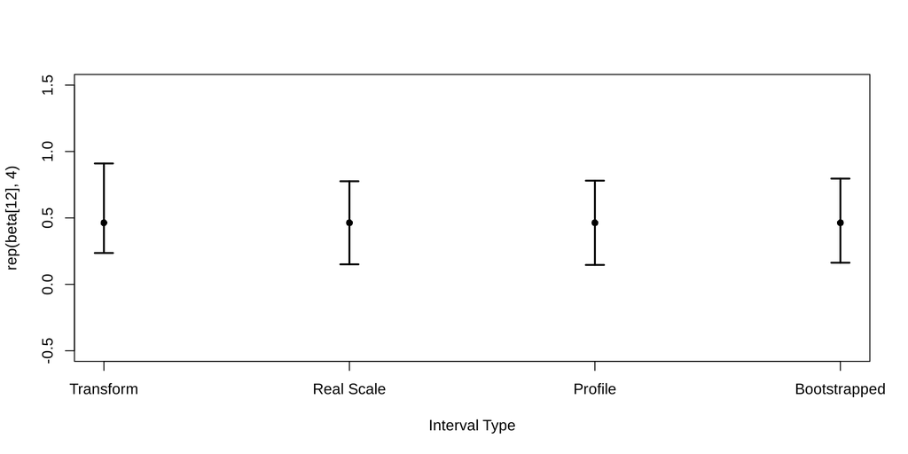

```r
boot.ci <- apply(boot.pars, 1, quantile, probs = c(0.025, 0.975) )

plot(1:4, rep(beta[12], 4), ylim = c(-0.5, 1.5), pch = 16, xlab = "Interval Type", xaxt = "n")
axis(1, at = 1:4, labels = c("Transform", "Real Scale", "Profile", "Bootstrapped"))

arrows(1:4, c(low_tr[12], low_r[12], exp(prof_int[1]), boot.ci[1,12]), 1:4,
  c(high_tr[12], high_r[12], exp(prof_int[2]), boot.ci[2,12]),
  length = 0.1, angle = 90,
  code = 3, col = "black", lwd = 2)
```

## Practical

- Run through your version of the sockeye code and create confidence intervals for different parameters.
- Compute residuals for this model?
- Use `DHARMa` to calculate randomized quantile residuals?
- Can you improve the model?

```r
res_dharma <- createDHARMa(
  simulatedResponse = sim_matrix, ## Each column a new simulation
  observedResponse = observed_y,  ## Observed data
  fittedPredictedResponse = predicted_y,  ## Fitted values (mu)
  integerResponse = FALSE
)

plot(res_dharma)
```

## End of Module

- Take home:
  - RTMB does not require many changes to do maximum likelihood estimation
  - Lots more to think about than using a function in R like `lm`
  - Can use `REPORT` and `ADREPORT` to get key values
  - Confidence intervals can be a little tricky, transform the CI or bootstrap/profile.
- Questions?